# Intro to Keras, Tensorflow and advanced NN

[figure not shown]

## Introduction

- TensorFlow is an end-to-end open source platform for ML
- It has a comprehensive, flexible ecosystem of tools and libraries
- Allows to easily build and deploy ML powered applications.
- Not only Neural Networks

## https://keras.io

- Keras is a high-level neural networks API (front-end), written in Python
- Capable of running on top of TensorFlow, CNTK, or Theano (backends)
- Built to simplify access to more complex backend libraries

## https://keras.io

Use Keras if you need a deep learning library that:

- Allows for easy and fast prototyping (through user friendliness, modularity, and extensibility).
- Supports both convolutional networks and recurrent networks, as well as combinations of the two.
- Runs seamlessly on CPU and GPU.

## https://tensorflow.org

More generic library for Machine Learning

Use *TensorFlow* if you want a finer level of control:

- Build your own NN layers
- Personalized cost function
- More complex architectures than those available on Keras

We will be mostly writing python code using Keras libraries, but "under the hood" Keras is using tensorflow libraries.

The documentation is at keras.io.

## If you want to use R instead of python

- Keras can run on R as well, it will look quite similar to the code in this notebook
- (but, you know, with <- instead of =)
- You find the docs here: https://keras.rstudio.com/
- Probably better support if you stick with python

## Some terminology

- A dataset in supervised learning is made of a number of (features, label) pairs
- Example, a dataset of diabetic patients is made of:
  - Features: information describing each patient (weight, height, blood pressure...)
  - Labels: whether each patient is diabetic or not (glucose levels higher or lower than...)
- Each (features, label) pair is also called a *sample* or *example*. Basically a data point
- Features are also sometimes called *inputs* when referred to something you feed to a NN
- Labels are compared to the NN's *outputs* to see how well the network is doing compared to the truth

## What is a tensor

The main variables in TensorFlow are, of course, tensors:

> A tensor is often thought of as a generalized matrix. That is, it could be a 1-D matrix (a vector), a 3-D matrix (something like a cube of numbers), even a 0-D matrix (a single number), or a higher dimensional structure that is harder to visualize. The dimension of the tensor is called its rank.

## What is a tensor

The main variables in TensorFlow are, of course, tensors:

> A tensor is often thought of as a generalized matrix. That is, it could be a 1-D matrix (a vector), a 3-D matrix (something like a cube of numbers), even a 0-D matrix (a single number), or a higher dimensional structure that is harder to visualize. The dimension of the tensor is called its rank.

## TensorFlow operates on tensors

> TensorFlow computations are expressed as stateful dataflow graphs. The name TensorFlow derives from the operations that such neural networks perform on multidimensional data arrays, which are referred to as tensors.

## The first step is to build a graph of operations

- NNs are defined in TensorFlow as graphs through which the data flows until the final result is produced
- Before we can do any operation on our data (images, etc) we need to build the graph of tensor operations
- When we have a full graph built from input to output, we can run (flow) our data (training or testing) through it.

## Tensors and data are *not* the same thing

- Tensors are, rather, a symbolic representation of the data
- Think about the function $g = f(x)$: as long as we do not assign a value to $x$, we will not have a fully computed $g$
- In this case, $g$ is the output tensor, $x$ the input tensor, $f$ the tensor operation (a Neural Network?)

## Example

- We have a set of color images of size $1000x1000$ pixels (1 megapixel) that we want to use on our NN
- We define tensors with shape $(n, 1000, 1000, 3)$
  - $n$ is the number of images that we are presenting to our network in one go (a "batch")
  - $1000x1000$: image pixels
  - $3$ is the number of channels (RGB)
  - Grayscale images tensors would have shape $(n, 1000, 1000, 1)$

## One thing to remember when operating on tensors

The dimensions between tensors coming out of the $i$-th node and those going into the $(i+1)$-th node *must* match:

- If each sample in our dataset is made of 10 features, the first (input) layer must accept a tensor of shape $(n, 10)$
- If the first layer in our NN outputs a 3D tensor, the second layer must accept a 3D tensor as input
- Check the documentation to make sure what input-output shapes are allowed ([example](https://keras.io/api/layers/convolution_layers/convolution1d/))

## Here's how a NN layer looks like in TensorFlow:

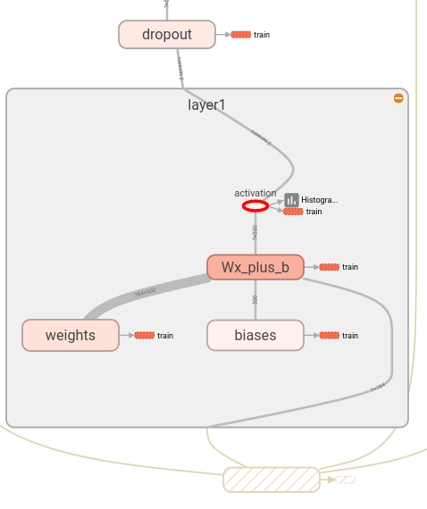

## Here is how a model is built and trained in Keras

```
#Multi-layer perceptron (one hidden layer)
model = Sequential()
model.add(Dense(3, input_dim=3, activation='sigmoid'))
model.add(Dense(1, activation='sigmoid'))

#Gradient descent algorithm, Mean Squared Error as Loss function
model.compile(optimizer='sgd', loss='mse', metrics=['mse'])

#Training for 10 iterations of the data (epochs)
history = model.fit(data, labels, epochs=10, batch=32)
...
```

What does each bit do?

## A neural network in Keras is called a Model

The simplest kind of model is of the Sequential kind:

```python
from tensorflow.keras.models import Sequential

model = Sequential()
```

This is an "empty" model, with no layers, no inputs or outputs are defined either.

Adding layer is easy:

```python
from tensorflow.keras.layers import Dense
model = Sequential()
model.add(Dense(units=4, activation='relu', input_dim=3))
model.add(Dense(units=2, activation='softmax'))
```

A "Dense" layer is a fully connected layer as the ones we have seen in Multi-layer Perceptrons. The above is equal to having this network:

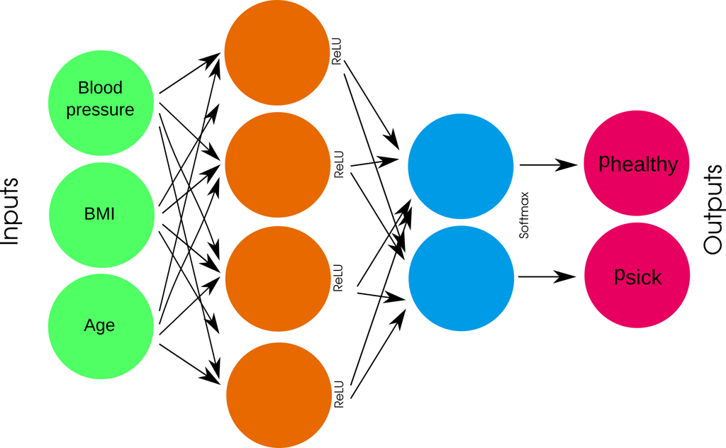

If we want to see the layers in the Model this far, we can just call:

```python
model.summary()
```

[output not shown]

Using "model.add()" keeps stacking layers on top of what we have:

```python
model.add(Dense(units=2, activation=None))
model.summary()
```

One can also declare the model in one go, by passing a list of layers to Sequential() like so:

```python
model = Sequential([
    Dense(units=4, activation='relu', input_dim=3),
    Dense(units=2, activation='softmax'),
    Dense(units=2, activation=None)
])

model.summary()
```

If we want to see the layers in the Model this far, we can just call:

```python
from tensorflow.keras.utils import plot_model

plot_model(model, "figures/simplenet_model.png", show_shapes=True)
```

## Small exercise

- Can you write code to make a simple NN model on Keras?
- Open the `exercises` jupyter notebook

## Keras layers (https://keras.io/api/layers/)

Common layers (we will cover most of these!)

- Trainable
  - Dense (fully connected/MLP)
  - Conv1D (2D/3D)
  - Recurrent: LSTM/GRU/Bidirectional
  - Embedding
  - Lambda (apply your own function)
- Non-trainable
  - Dropout
  - Flatten
  - BatchNormalization
  - MaxPooling1D (2D/3D)
  - Merge (add/subtract/concatenate)
  - Activation (Softmax/ReLU/Sigmoid/...)

## Compiling a model

Once we have defined a model we want to "compile" it

This means chosing a Loss function and an Optimizer (the algorithm that finds the minimum loss possible).

```python
model.compile(optimizer='rmsprop',                    #adaptive learning rate method
              loss='sparse_categorical_crossentropy', #loss function for classification problems with integer labels
              metrics=['accuracy'])                   #the metric doesn't influence the training

model.optimizer.get_config()
```

## Losses (https://keras.io/api/losses/)

These are the functions used to evaluate and train the neural network

Common losses for classification problems:

- CategoricalCrossentropy
- SparseCategoricalCrossentropy
- KLDivergence

Common losses for regression problems:

- MeanSquaredError
- MeanAbsoluteError

## Metrics (https://keras.io/api/metrics/)

Common metrics for classification:

- Accuracy/CategoricalAccuracy (respectively for integer labels or one-hot labels)
- SparseCategoricalCrossentropy/CategoricalCrossentropy (integer/one-hot labels)
- Precision/Recall
- AUC

Common metrics for regression:

- MeanSquaredError
- MeanAbsoluteError

## Metrics (https://keras.io/api/metrics/)

Notice the "metrics" parameter, which accepts a list of values. Multiple metrics can be shown during training. Metrics are only to visualize how the training is going, they don't have an effect on training itself

```python
from tensorflow.keras.optimizers import RMSprop
model.compile(optimizer=RMSprop(learning_rate=1.0),   #adaptive learning rate method
              loss='sparse_categorical_crossentropy', #loss function for classification problems with integer labels
              metrics=['accuracy', 'recall'])         #the metric doesn't influence the training
```

## Optimizers (https://keras.io/api/optimizers/)

- They are algorithms for gradient descent
- A few to choose from:
  - SGD (Stochastic Gradient Descent)
  - RMSprop (Root Mean Square propagation)
  - Adadelta (Adaptive delta)
  - Adam (Adaptive Moment estimation)

## Gradient Descent

We have seen how gradient descent works:

For each epoch:

- Get predicted $y$ ($ŷ$) for all $N$ samples
- Calculate error (loss)
- Calculate all gradients (backprop)
- Apply gradients to weights

Pros/cons:

- Stable procedure
- Guarantees lower error at next step
- Will get stuck at local minimum

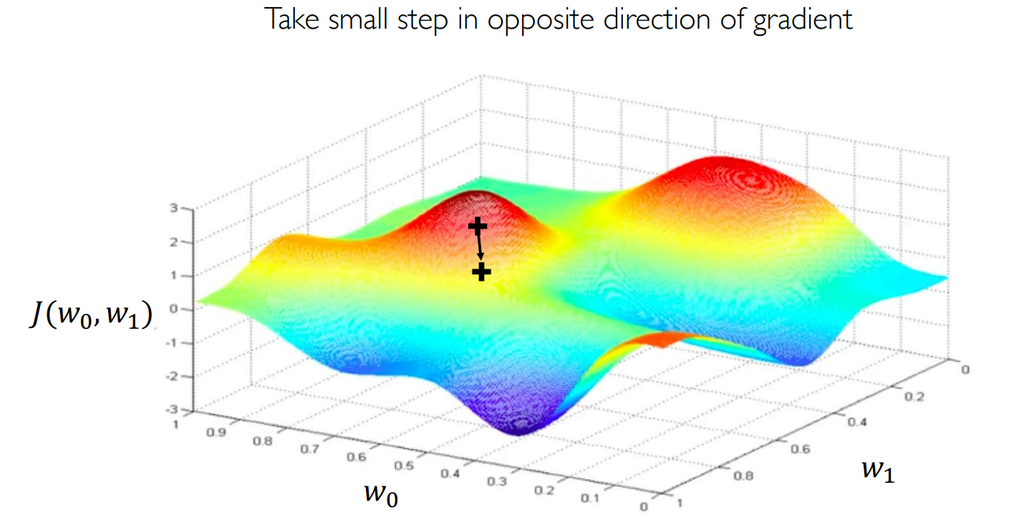

## Stochastic Gradient Descent

For each epoch:

- Divide data in batch blocks of size $n < N$
- For each of the $N/n$ blocks:
  - Get predicted $y$ for $n$ samples
  - Calculate partial loss
  - Calculate gradients (backprop)
  - Apply gradients to weights

Pros/cons:

- Noisy gradients
- Error will still go down overall
- Less likely to get stuck at local minimum

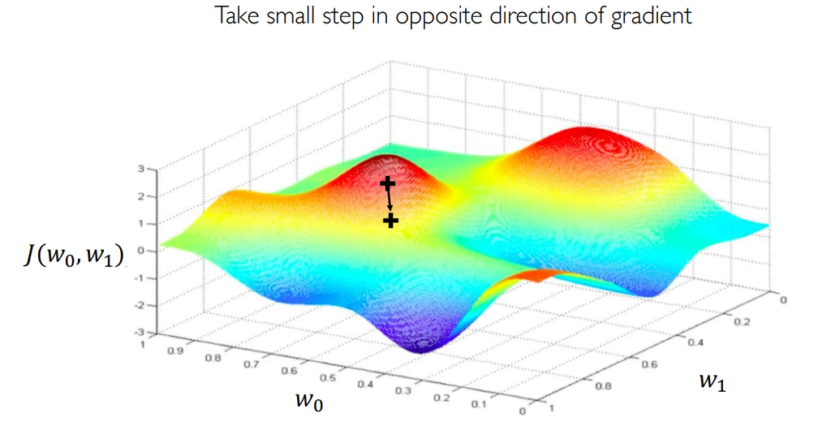

## Optimizers (https://keras.io/api/optimizers/)

We need to choose a learning rate to multiply to our gradient. If it is too small, we risk taking too long to get to a minimum

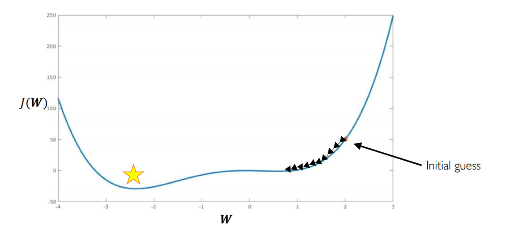

## Optimizers (https://keras.io/api/optimizers/)

If it is too large, the network risks becoming unstable, explode

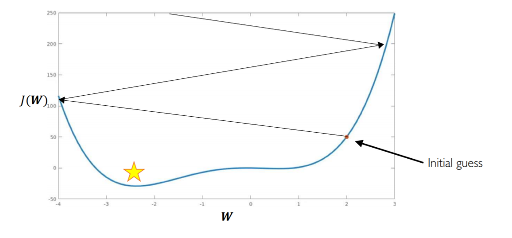

Let's test different optimization strategies on Tensorflow playground: http://playground.tensorflow.org

## Optimizers (https://keras.io/api/optimizers/)

Luckily there are algorithms to address these issues:

- Increase descent speed when past gradients agree with current, slow down otherwise (momentum)
- Annealing (decrease learning rate with passing time)
- Different learning rates for different parameters
- Adaptive learning rate based on gradient

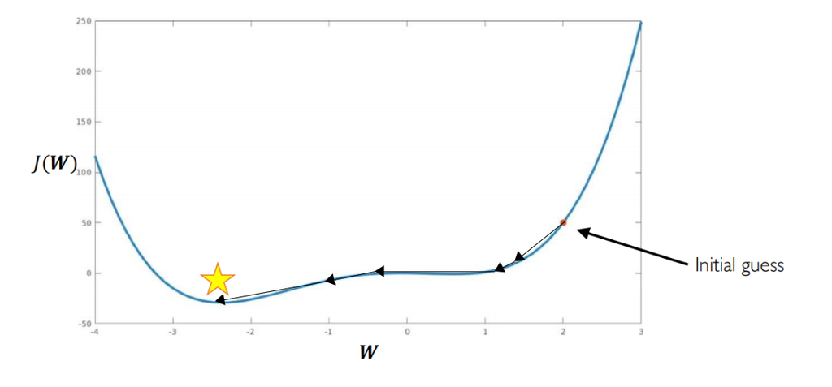

## Optimizers (https://keras.io/api/optimizers/)

- They are algorithms for gradient descent
- A few to choose from:
  - SGD (stochastic gradient descent)
    - One learning rate, fixed
    - Old, but works well with Nesterov momentum
  - RMSprop
    - One learning rate per parameter
    - Adaptive learning rate (divide by squared mean of past gradients)
  - Adadelta (adaptive learning rate)
    - Similar to RMSprop, no need to set initial learning rate
  - Adam (Adaptive moment estimation)
    - Combines pros from RMSprop, Adadelta, works well with most problems

## Optimizers (https://keras.io/api/optimizers/)

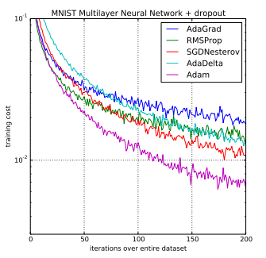

("Adam: A Method for Stochastic Optimization", 2015)

## Training the model: fit() function (https://keras.io/api/models/model_training_apis/)

- We are almost ready to train the model, I swear
- fit() is a method of the Model, actually launches training on a dataset with features and labels
- X_train, y_train: features and labels
- batch: how many samples between each weight update
- epochs: how many times we iterate through the dataset
- validation_data: used to evaluate the model at the end of every epoch, NOT used for training

```
model.fit(X_train, y_train, validation_data=(X_val, y_val), batch=32, epochs=10)
```

## Training the model: fit() function (https://keras.io/api/models/model_training_apis/)

- Ok, last thing we need is the actual data, then we can train the model

```
model.fit(X_train, y_train, validation_data=(X_val, y_val), batch=32, epochs=10, validation_data=(X_val, y_val))
```

## What is this validation thing? Do I really need it?

- Yes, yes you do
- Helps understanding if the model is learning anything useful
- Take some of your labelled data, set it aside, call it validation set and don't train on it
- Evaluate model on validation set at the end of each epoch, see if model works on unseen data
- If it works well on training set but not on validation set, you're overfitting

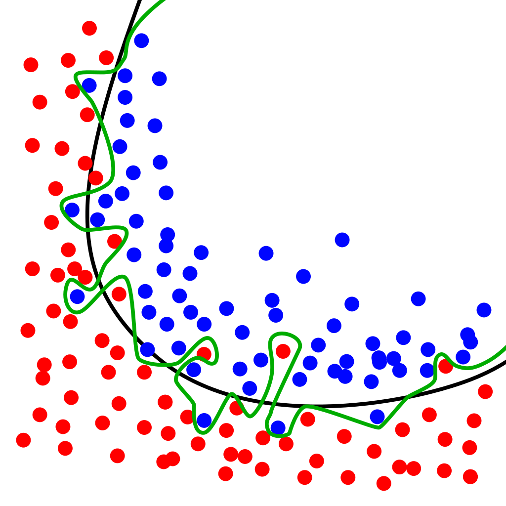